# Конфигурирование HTTP-сервера Apache

Лабораторная работа №5

Элсаиед Адел

Российский университет дружбы народов, Москва, Россия

3 января 2026

# Цели и задачи работы

## Цель лабораторной работы

Приобретение практических навыков расширенного конфигурирования HTTP-сервера Apache в части обеспечения безопасности соединения с использованием протокола HTTPS, а также настройки поддержки серверного языка PHP.

# Выполнение работы

## Генерация SSL-сертификата

На виртуальной машине **server** был создан каталог для хранения закрытых ключей SSL и сгенерирован самоподписанный сертификат с использованием утилиты OpenSSL.

В процессе генерации были заданы параметры Distinguished Name, включая доменное имя веб-сервера и данные организации.

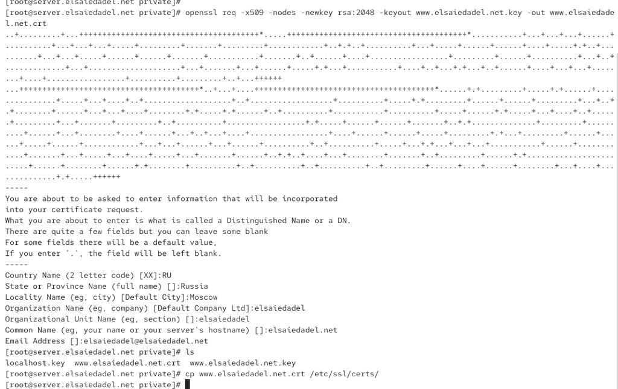

Генерация SSL-сертификата

## Размещение сертификата и ключа

После генерации была выполнена проверка наличия созданных файлов. SSL-сертификат был перемещён в системный каталог сертификатов, предназначенный для использования веб-сервером Apache.

[figure not shown]

## Настройка виртуального хоста Apache

Был отредактирован конфигурационный файл виртуального хоста Apache.  
Настроено автоматическое перенаправление HTTP-запросов на HTTPS и включена поддержка SSL для порта 443 с указанием путей к сертификату и закрытому ключу.

[figure not shown]

## Проверка HTTPS-соединения

После применения конфигурации выполнен доступ к веб-серверу из браузера клиентской виртуальной машины. Зафиксировано автоматическое перенаправление на защищённое HTTPS-соединение.

[figure not shown]

Проверка HTTPS в браузере

## Просмотр сведений сертификата

В браузере были просмотрены сведения установленного SSL-сертификата. Подтверждено соответствие доменного имени и параметров субъекта сертификата заданным значениям.

[figure not shown]

## Настройка PHP на сервере

Для проверки работы PHP в каталоге веб-сайта был создан файл `index.php`, содержащий вызов функции `phpinfo()`.  
Произведена настройка прав доступа и восстановление контекста безопасности SELinux.

[figure not shown]

## Проверка работы PHP

При обращении к веб-серверу через браузер была успешно отображена страница с информацией о версии PHP, параметрах сборки и конфигурации окружения.

[figure not shown]

## Обновление provisioning-скриптов

Для обеспечения воспроизводимости конфигурации были скопированы файлы виртуальных хостов, веб-контент и SSL-сертификаты в каталог provisioning.  
В скрипт `http.sh` добавлены установка PHP, настройка межсетевого экрана и автоматический запуск сервиса httpd.

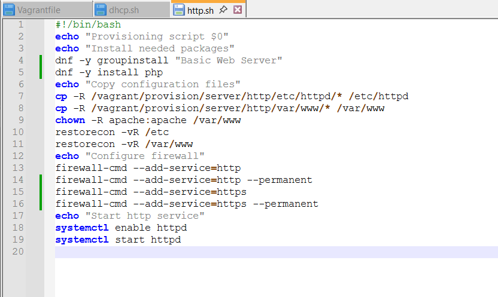

Обновление provisioning-скрипта

# Выводы

## Вывод

В ходе лабораторной работы был сконфигурирован HTTP-сервер Apache для работы через защищённый протокол HTTPS. Сгенерирован и применён SSL-сертификат, настроено автоматическое перенаправление HTTP-запросов на HTTPS и обеспечена поддержка PHP. Внесённые изменения интегрированы в систему автоматического развёртывания Vagrant, что обеспечивает воспроизводимость и удобство управления серверной конфигурацией.